# First hands-on for the DMI course

Males dominate the dataset and have higher chest pain type, abnormal thalassemia, and major vessels (ca). Gender-based differences exist in exercise-induced angina and resting ECG, potentially impacting heart disease risk.

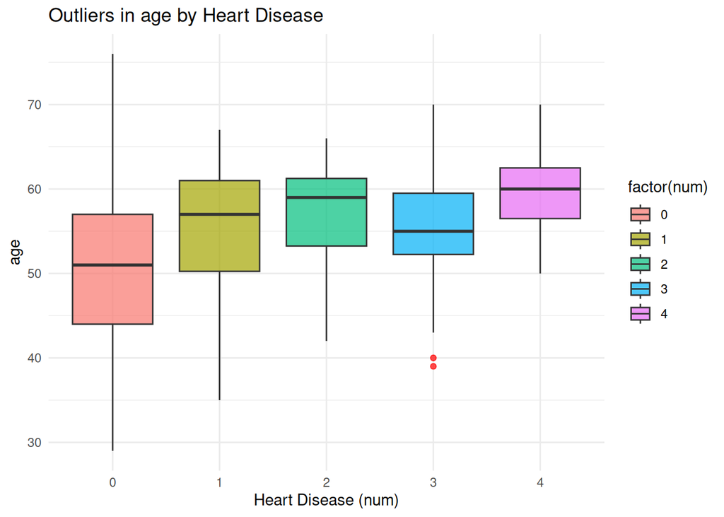

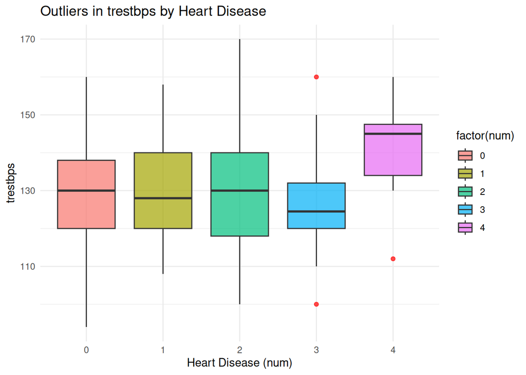

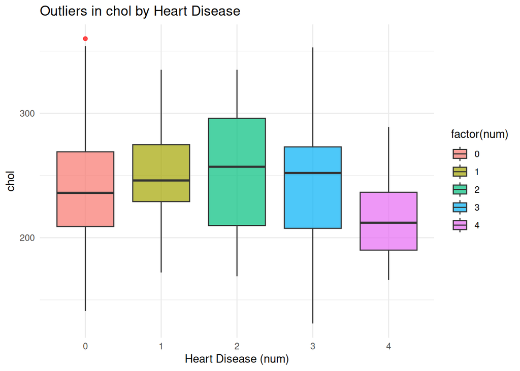

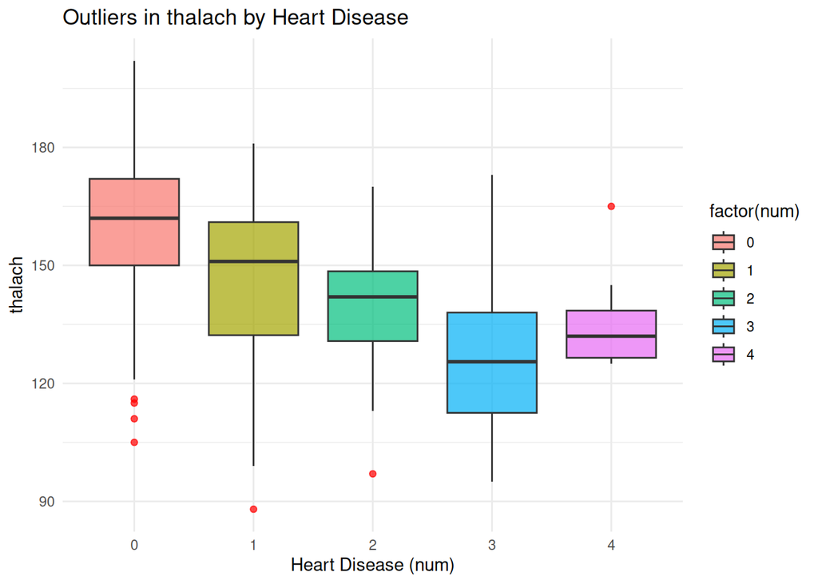

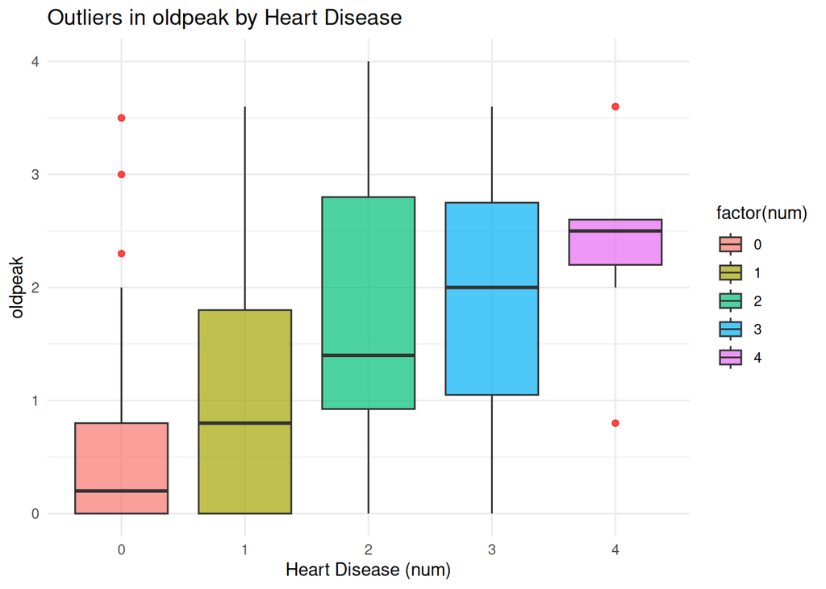

```r
# 8. Look at outliers in numerical values depending on several factors
for (var in num_vars) {
  print(
    ggplot(data_frame, aes_string(x = "factor(num)", y = var, fill = "factor(num)")) +
      geom_boxplot(alpha = 0.7, outlier.color = "red") +
      scale_fill_manual(values = color_palette) +
      labs(title = paste("Outliers in", var, "by Heart Disease"), x = "Heart Disease (num)", y = var) +
      theme_minimal()
  )
}
```

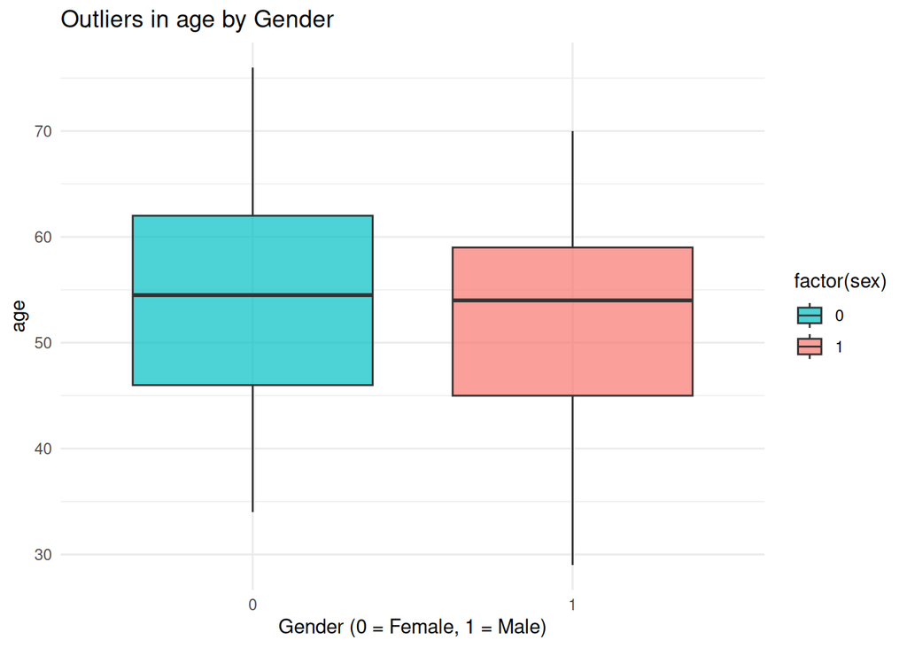

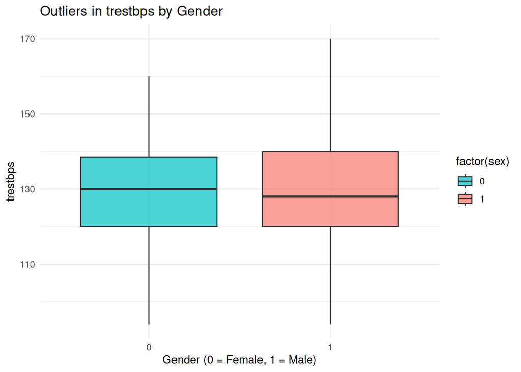

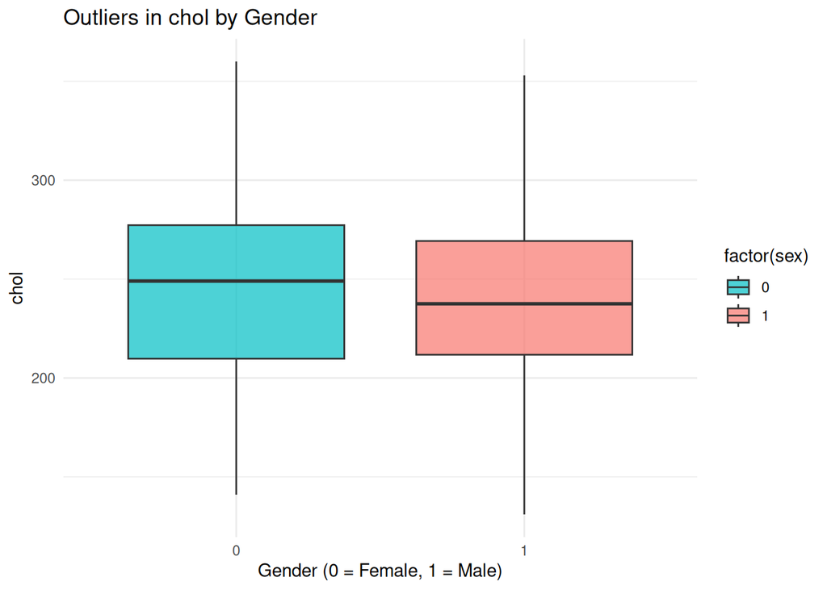

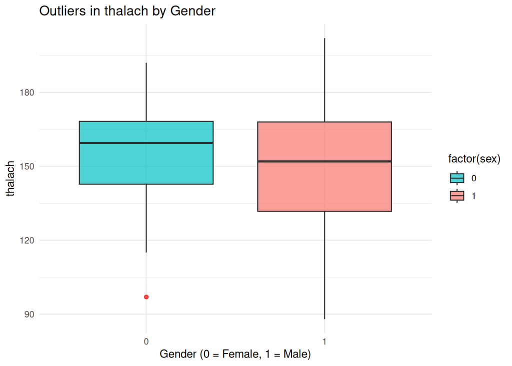

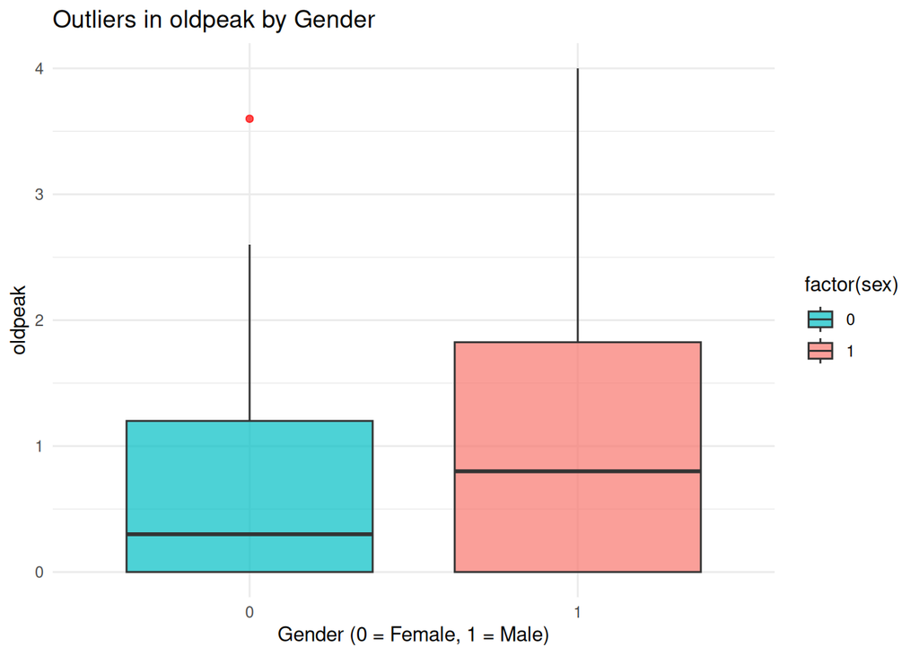

```r
for (var in num_vars) {
  print(
    ggplot(data_frame, aes_string(x = "factor(sex)", y = var, fill = "factor(sex)")) +
      geom_boxplot(alpha = 0.7, outlier.color = "red") +
      scale_fill_manual(values = c("#00BFC4", "#F8766D")) +
      labs(title = paste("Outliers in", var, "by Gender"), x = "Gender (0 = Female, 1 = Male)", y = var) +
      theme_minimal()
  )
}
```

Heart disease severity correlates with increasing oldpeak and decreasing thalach, with males, higher cp, thal 7, and ca > 0 more affected. Chol and trestbps show variability but are weaker predictors, while outliers have minimal impact on trends. Lifestyle factors like alcohol and smoking were not assessed.

## Create visualizations in order to show which variables seem to be more associated with heart disease

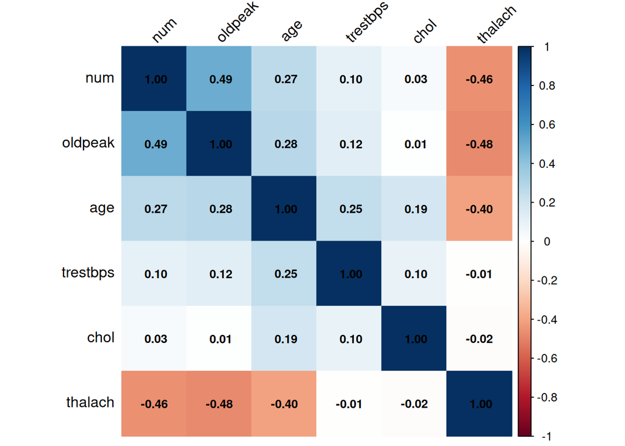

```r
library(corrplot)
library(dplyr)
# Visualize Correlation Matrix
# Select relevant columns
selected_data <- data_frame[, c("num", "oldpeak", "age", "trestbps", "chol", "thalach")]

# Ensure columns are numeric
selected_data <- selected_data %>%
  mutate(across(everything(), as.numeric))

# Correlation matrix with the numeric measurements
cor_matrix <- cor(selected_data, method = "spearman")
corrplot(cor_matrix, method = "color", type = "full", addCoef.col = "black",
         tl.col = "black", tl.srt = 45, number.cex = 0.8)
```

# 2. Difference in mortality rates in hospitalized COVID-19 patients

Using the supplementary material from the [Difference in mortality rates in hospitalized COVID-19 patients identified by cytokine profile clustering using a machine learning approach: An outcome prediction alternative](https://www.frontiersin.org/articles/10.3389/fmed.2022.987182/full), perform the following tasks

## Reproduce Figure 1 from the publication

```r
library(readxl)
library(ggplot2)
library(dplyr)
library(gridExtra)
library(grid)

table <- read_excel("data/Table_1.XLSX")

# Figure 1, part 1
# Standardize column names
table <- table %>%
  rename_with(~ gsub("\\s+", "_", .)) %>%
  rename_with(tolower)

# Step 1: Remove exact duplicate rows
table_unique <- table %>% distinct()    # Two rows were removed

# Further explore the data: check for duplicate ids in table_unique
duplicates_table_unique_1 <- table_unique %>%
  group_by(id) %>%
  filter(n() > 1)
```

We identified 6 IDs that appear twice in the dataset, with different values for their corresponding measurements. Since we cannot determine which of the two entries is the correct or most reliable one, keeping them could introduce inconsistencies and potential bias in the analysis. Rather than arbitrarily selecting one of the rows, we opt to remove these ambiguous cases to ensure data integrity.

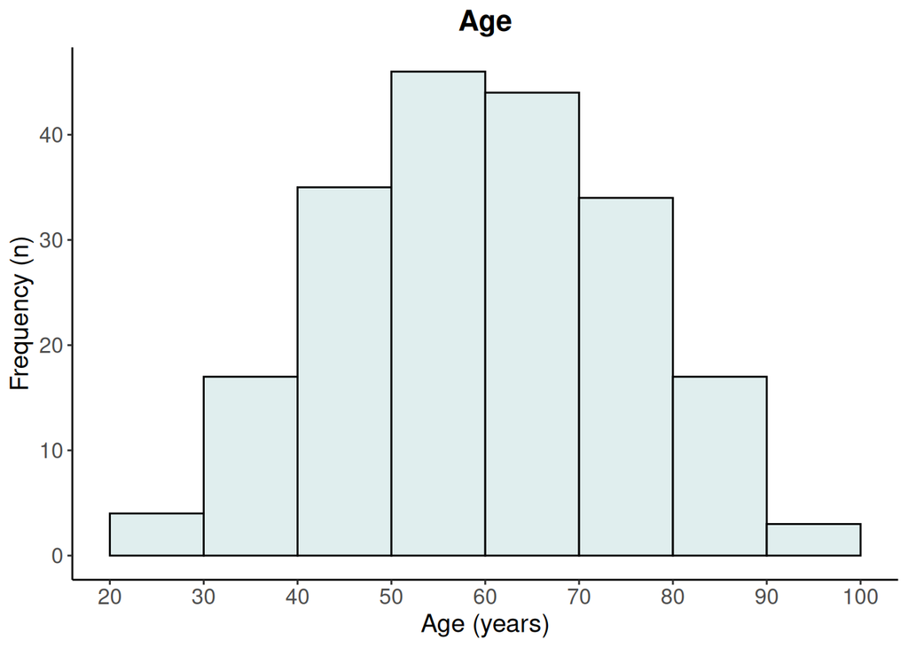

```r
# Remove rows that share the exact same id
table_unique <- table_unique %>%
  group_by(id) %>%
  filter(n() == 1) %>%
  ungroup()

# Create an Age Group column for plotting
table_unique <- table_unique %>%
  mutate(age_group = cut(age, breaks = seq(20, 100, by = 10), right = FALSE, include.lowest = TRUE))

# Create the histogram with adjustments for styling
ggplot(data = table_unique, mapping = aes(x = age)) +
  geom_histogram(
    binwidth = 10,
    color = "black",
    fill = "#E0EEEE",
    boundary = 20
  ) +
  scale_x_continuous(breaks = seq(20, 100, by = 10), limits = c(20, 100)) +
  labs(
    x = "Age (years)",
    y = "Frequency (n)",
    title = "Age"
  ) +
  theme_classic() +
  theme(
    axis.text.x = element_text(size = 12),
    axis.text.y = element_text(size = 12),
    axis.title.x = element_text(size = 14),
    axis.title.y = element_text(size = 14),
    plot.title = element_text(size = 16, face = "bold", hjust = 0.5)
  )
```

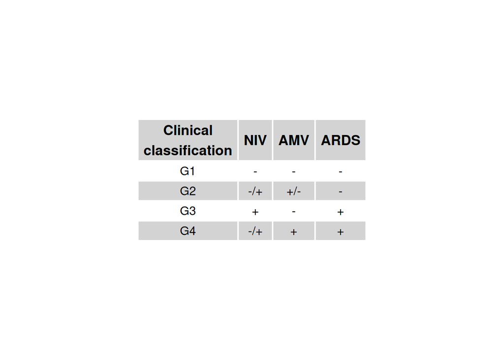

```r
# Figure 1, part 2
# Define the table data
data <- matrix(c("G1", "-",  "-",   "-",
                 "G2", "-/+", "+/-", "-",
                 "G3", "+",   "-",   "+",
                 "G4", "-/+", "+",   "+"),
               nrow = 4, ncol = 4, byrow = TRUE)

colnames <- c("Clinical\nclassification", "NIV", "AMV", "ARDS")

# Create the tableGrob
table <- tableGrob(data,
                   rows = NULL, # No row names
                   cols = colnames)

# Define the theme with alternating row colors and centered text
theme <- ttheme_minimal(
  core = list(
    fg_params = list(hjust = 0.5, x = 0.5, fontsize = 12), # Center-align and font size
    bg_params = list(fill = c(rep(c("white", "lightgray"), length.out = nrow(data))),
                     col = "white") # Alternating row colors with white gridlines
  ),
  colhead = list(
    fg_params = list(fontsize = 14, fontface = "bold"), # Header style
    bg_params = list(fill = "lightgray", col = "white") # Header background
  )
)

# Recreate the table with the theme
table <- tableGrob(data, rows = NULL, cols = colnames, theme = theme)

# Add white lines (gridlines) between rows and columns
table$grobs <- lapply(table$grobs, function(grob) {
  if (inherits(grob, "rect")) {
    grob$gp$col <- "white" # Set gridline color to white
    grob$gp$lwd <- 2       # Set line width
  }
  return(grob)
})

# Add a title
title <- textGrob("Definition of the clinical classification",
                  gp = gpar(fontsize = 14, fontface = "bold"))

# Combine title and table into a single plot with closer spacing
grid.newpage()
grid.arrange(table, ncol = 1)
```

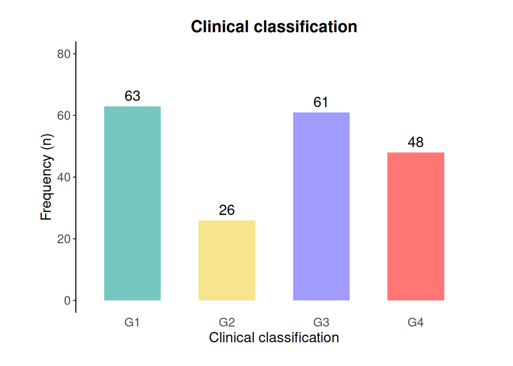

```r
#Figures 1c and 1d
# Classify patients into G1, G2, G3, or G4
table_unique <- table_unique %>%
  mutate(
    group = case_when(
      use_of_niv == "No" & use_of_amv == "No" & days_with_ards == 0 ~ "G1",
      days_with_ards == 0 ~ "G2",
      use_of_niv == "Yes" & use_of_amv == "No" & days_with_ards > 0 ~ "G3",
      use_of_amv == "Yes" & days_with_ards > 0 ~ "G4"
    )
  ) %>%
  filter(!is.na(group))  # Remove NA values

# Count patients in each group
group_counts <- table_unique %>%
  count(group)

# Create Figure 1C - Clinical Classification Bar Plot
fig_1c <- ggplot(group_counts, aes(x = group, y = n, fill = group)) +
  geom_bar(stat = "identity", width = 0.6) +
  geom_text(aes(label = n), vjust = -0.5, size = 5, fontface = "plain") +  # Not bold
  scale_fill_manual(values = c("G1" = "#76c7c0", "G2" = "#f6e58d", "G3" = "#a29bfe", "G4" = "#ff7675")) +
  scale_y_continuous(breaks = seq(0, 80, by = 20), limits = c(0, 80)) +
  labs(title = "Clinical classification", x = "Clinical classification", y = "Frequency (n)") +
  theme_classic() +
  theme(
    plot.title = element_text(size = 16, face = "bold", hjust = 0.5),
    axis.text.x = element_text(size = 12, face = "plain"),
    axis.text.y = element_text(size = 12),
    axis.title.x = element_text(size = 14),
    axis.title.y = element_text(size = 14),
    axis.line.x = element_blank(),  # Remove X-axis line
    axis.ticks.x = element_blank(),  # Remove X-axis ticks
    legend.position = "none",  # Remove legend
    plot.margin = margin(20, 40, 20, 40)  # Increase width spacing
  )

# Count number of deaths
vital_counts <- table_unique %>%
  count(death) %>%
  arrange(match(death, c("No", "Yes")))

# Create Figure 1D - Vital Status Bar Plot
fig_1d <- ggplot(vital_counts %>% filter(death %in% c("No", "Yes")), aes(x = death, y = n, fill = death)) +
  geom_bar(stat = "identity", width = 0.6) +
  geom_text(aes(label = n), vjust = -0.2, size = 5, fontface = "plain") +  # Keep labels exactly on top
  scale_fill_manual(values = c("No" = "#76c7c0", "Yes" = "#f6e58d")) +
  scale_y_continuous(breaks = seq(0, 160, by = 50), limits = c(0, 160)) +  # Allow space for labels
  labs(title = "Vital status", x = "Death", y = "Frequency (n)") +
  theme_classic() +
  theme(
    plot.title = element_text(size = 14, face = "bold", hjust = 0.5),
    axis.text.x = element_text(size = 12, face = "plain"),
    axis.text.y = element_text(size = 12),
    axis.title.x = element_text(size = 14),
    axis.title.y = element_text(size = 14),
    axis.line.x = element_blank(),  # Remove X-axis line
    axis.ticks.x = element_blank(),  # Remove X-axis ticks
    legend.position = "none",  # Remove legend
    plot.margin = margin(20, 40, 20, 40)  # Adjust spacing
  )


# Display 1c, and 1d
print(fig_1c)
```

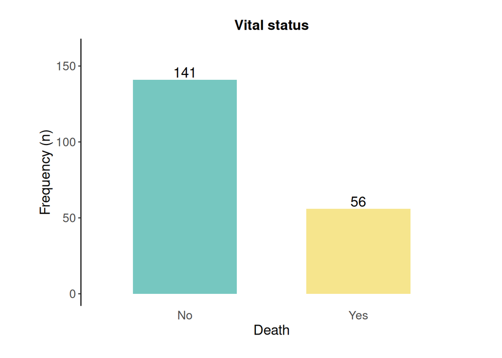

```r
print(fig_1d)
```

## Reproduce Figure 2 from the publication

but instead of representing the clusters in the annotation, represent the groups (G1 to G4)

```r
library(readxl)
library(dplyr)
library(tidyr)
library(pheatmap)

# 1. Read the data from the Excel document
raw_data <- read_excel("data/Table_2.XLSX", 1)
# View the first few rows
head(raw_data)
```

```
## # A tibble: 6 × 27
##   ID      ...2  Laboratoy and Cytoki…¹ ...4  ...5  ...6  ...7  ...8  ...9  ...10
##   <chr>   <chr> <chr>                  <chr> <chr> <chr> <chr> <chr> <chr> <chr>
## 1 <NA>    Day   IL-1β                  IL-6  IL-10 IFN-ɑ TNF-ɑ IL-8  G-CSF IFN-γ
## 2 COAG-H… 1     0                      4.59… 4.05… 2.69  0.72  37.6… 3.7   4.68
## 3 COAG-H… 1     0                      0.5   9.16  2.52  1.4   8.66  2.52  3.72
## 4 COAG-H… 1     0                      147.… 4.7   0.4   0     133.… 10.3… 3.64…
## 5 <NA>    3     0                      169.5 0     2.28… 1.40… 96.7… 13.0… 4.08…
## 6 <NA>    5     NI                     NI    NI    NI    NI    NI    NI    NI
## # ℹ abbreviated name: ¹`Laboratoy and Cytokine Measurements`
## # ℹ 17 more variables: ...11 <chr>, ...12 <chr>, ...13 <chr>, ...14 <chr>,
## #   ...15 <chr>, ...16 <chr>, ...17 <chr>, ...18 <chr>, ...19 <chr>,
## #   ...20 <chr>, ...21 <chr>, `Blood Count Data` <chr>, ...23 <chr>,
## #   ...24 <chr>, ...25 <chr>, ...26 <chr>, ...27 <chr>
```

```r
# The first row contains a header
colnames(raw_data) <- raw_data[1, ] # Set the first row as column names
clean_data <- tail(raw_data,-1)      # Remove the first row

# For more clarity, make sure the first column is named "id"
colnames(clean_data)[1] <- "id"

# Check data types of the data frame
str(clean_data)           # All columns have type 'char'
```

```
## tibble [445 × 27] (S3: tbl_df/tbl/data.frame)
##  $ id                               : chr [1:445] "COAG-HSJD-001" "COAG-HSJD-002" "COAG-HSJD-003" NA ...
##  $ Day                              : chr [1:445] "1" "1" "1" "3" ...
##  $ IL-1β                            : chr [1:445] "0" "0" "0" "0" ...
##  $ IL-6                             : chr [1:445] "4.5999999999999996" "0.5" "147.69999999999999" "169.5" ...
##  $ IL-10                            : chr [1:445] "4.0599999999999996" "9.16" "4.7" "0" ...
##  $ IFN-ɑ                            : chr [1:445] "2.69" "2.52" "0.4" "2.2815259999999999" ...
##  $ TNF-ɑ                            : chr [1:445] "0.72" "1.4" "0" "1.4033" ...
##  $ IL-8                             : chr [1:445] "37.619999999999997" "8.66" "133.52510000000001" "96.705349999999996" ...
##  $ G-CSF                            : chr [1:445] "3.7" "2.52" "10.344060000000001" "13.041069999999999" ...
##  $ IFN-γ                            : chr [1:445] "4.68" "3.72" "3.6417510000000002" "4.0869479999999996" ...
##  $ CCL3                             : chr [1:445] "4.07" "5.07" "20.068390000000001" "5.975409" ...
##  $ CXCL10                           : chr [1:445] "2387.96" "1490.02" "2135.7710000000002" "1025.501" ...
##  $ CCL2                             : chr [1:445] "58.88" "13.74" "901.47990000000004" "263.40839999999997" ...
##  $ IL-38                            : chr [1:445] "566.79" "655.42" "888.09339999999997" "951.71619999999996" ...
##  $ PT                               : chr [1:445] "13.7" "13.2" "13" "14.3" ...
##  $ TTP                              : chr [1:445] "77" "82" "84" "73" ...
##  $ D-Dimer                          : chr [1:445] "359" "NI" "1986" "993" ...
##  $ Fibrinogen                       : chr [1:445] "707" "NI" "518" "707" ...
##  $ CRP                              : chr [1:445] "26.47" "1.1200000000000001" "36.92" "37.07" ...
##  $ Procalcitonin                    : chr [1:445] "0.21" "0.113" "3.67" "0" ...
##  $ Ferritin                         : chr [1:445] "547.6" "509.1" ">4000" "227764.2" ...
##  $ Hemoglobin (g/dL)                : chr [1:445] "11.9" "13.7" "13.9" "12.3" ...
##  $ Platelets (units/µl)             : chr [1:445] "200" "303" "116" "114" ...
##  $ Leucocytes (units/mm^3)          : chr [1:445] "5.3" "127" "6.26" "2.33" ...
##  $ Lymphocytes (units/mm^3)         : chr [1:445] "0.53" "1.1399999999999999" "0.93" "0.28000000000000003" ...
##  $ Neutrophils (units/mm^3)         : chr [1:445] "4.18" "10.94" "5.17" "1.94" ...
##  $ Eritrocytes (millions/microliter): chr [1:445] "4.12" "5.13" "4.26" "3.81" ...
```

```r
# 2. Transform cytokine data to numeric type for further processing
numeric_columns <- colnames(clean_data)[2:ncol(clean_data)]                    # Select columns except for the first one (id)
clean_data[numeric_columns] <- lapply(clean_data[numeric_columns], as.numeric) # Convert to numeric type, use the lapply function to apply as.numeric to each element of the numeric_columns
```

[output not shown]

```r
# Verify the columns have the correct type
str(clean_data)
```

```
## tibble [445 × 27] (S3: tbl_df/tbl/data.frame)
##  $ id                               : chr [1:445] "COAG-HSJD-001" "COAG-HSJD-002" "COAG-HSJD-003" NA ...
##  $ Day                              : num [1:445] 1 1 1 3 5 7 9 11 1 1 ...
##  $ IL-1β                            : num [1:445] 0 0 0 0 NA NA NA NA 0 0 ...
##  $ IL-6                             : num [1:445] 4.6 0.5 147.7 169.5 NA ...
##  $ IL-10                            : num [1:445] 4.06 9.16 4.7 0 NA NA NA NA 4.8 7.35 ...
##  $ IFN-ɑ                            : num [1:445] 2.69 2.52 0.4 2.28 NA ...
##  $ TNF-ɑ                            : num [1:445] 0.72 1.4 0 1.4 NA ...
##  $ IL-8                             : num [1:445] 37.62 8.66 133.53 96.71 NA ...
##  $ G-CSF                            : num [1:445] 3.7 2.52 10.34 13.04 NA ...
##  $ IFN-γ                            : num [1:445] 4.68 3.72 3.64 4.09 NA ...
##  $ CCL3                             : num [1:445] 4.07 5.07 20.07 5.98 NA ...
##  $ CXCL10                           : num [1:445] 2388 1490 2136 1026 NA ...
##  $ CCL2                             : num [1:445] 58.9 13.7 901.5 263.4 NA ...
##  $ IL-38                            : num [1:445] 567 655 888 952 NA ...
##  $ PT                               : num [1:445] 13.7 13.2 13 14.3 12.5 117 11.3 10.9 13.2 13 ...
##  $ TTP                              : num [1:445] 77 82 84 73 89 99 104 111 85 84 ...
##  $ D-Dimer                          : num [1:445] 359 NA 1986 993 3393 ...
##  $ Fibrinogen                       : num [1:445] 707 NA 518 707 425 229 191 207 NA 379 ...
##  $ CRP                              : num [1:445] 26.47 1.12 36.92 37.07 13.27 ...
##  $ Procalcitonin                    : num [1:445] 0.21 0.113 3.67 0 0 0 0 0 0.131 NA ...
##  $ Ferritin                         : num [1:445] 548 509 NA 227764 740000 ...
##  $ Hemoglobin (g/dL)                : num [1:445] 11.9 13.7 13.9 12.3 NA NA NA NA 12.5 18.2 ...
##  $ Platelets (units/µl)             : num [1:445] 200 303 116 114 NA NA NA NA 178 398 ...
##  $ Leucocytes (units/mm^3)          : num [1:445] 5.3 127 6.26 2.33 NA NA NA NA 55 291 ...
##  $ Lymphocytes (units/mm^3)         : num [1:445] 0.53 1.14 0.93 0.28 NA NA NA NA 627 9.6 ...
##  $ Neutrophils (units/mm^3)         : num [1:445] 4.18 10.94 5.17 1.94 NA ...
##  $ Eritrocytes (millions/microliter): num [1:445] 4.12 5.13 4.26 3.81 NA NA NA NA 4.5 6.28 ...
```

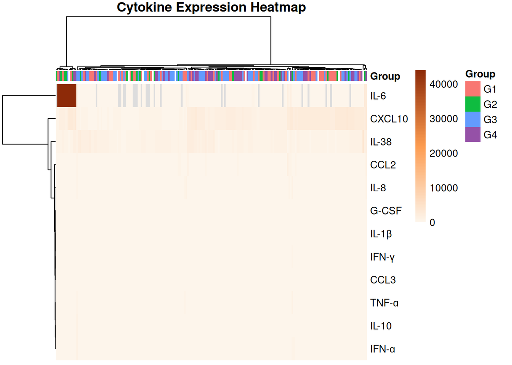

```r
# 3. Handle multiple measurements per patient
# First of all, remove leading/trailing spaces in id
clean_data$id <- trimws(clean_data$id)

# Then, fill in the missing id values for rows with 'NA' using the fill() function, for the
# data aggregation to work correctly
clean_data <- clean_data %>%
  fill(id, .direction = "down")

# Some patients have multiple measurements, taken on different days. To aggregate their cytokine levels, we choose to replace multiple measurements by their mean
aggregated_data <- clean_data %>%
  group_by(id) %>%
  summarise(across(everything(), ~mean(.x, na.rm = TRUE)))

# Merge patient group information (G1-G4)
aggregated_data <- left_join(aggregated_data, table_unique %>% select(id, group, death, gender), by = "id")

# Remove unnecessary columns and prepare the data for heatmap
# Only keep the first 14 columns of the data frame, except column Day (which contain the cytokine measurements we are interested in plotting)
new_aggregated_data <- select(aggregated_data, c(id, colnames(aggregated_data)[3:14], group))

# Create annotation data frame for G1-G4 groups
annotation_col_group <- data.frame(Group = factor(new_aggregated_data$group))

# Define colors for the groups
group_colors <- list(Group = c("G1" = "#F87772", "G2" = "#0FBC40", "G3" = "#639BFE", "G4" = "#9551A7"))

# Make sure we are working with a data.frame and not a tibble
new_aggregated_data <- as.data.frame(new_aggregated_data)
# Set patient id as rownames
rownames(new_aggregated_data) <- new_aggregated_data$id

# Assign row names according to patient id
rownames(annotation_col_group) <- new_aggregated_data$id

# Create heatmap
# Convert to numeric matrix for heatmap, preserve patient id as row names
data_matrix <- as.matrix(new_aggregated_data[,-c(1, ncol(new_aggregated_data))]) # Exclude patient id and group

# Generate the heatmap
pheatmap(
  t(data_matrix),  # Transpose to have cytokines on the Y-axis
  color = colorRampPalette(c("#FDF5EB", "#FD9C50","#8D2A08"))(100),  # Define heatmap colors
  cluster_rows = TRUE,
  cluster_cols = TRUE,
  show_rownames = TRUE,
  show_colnames = FALSE,
  fontsize_row = 10,
  main = "Cytokine Expression Heatmap",
  annotation_col = annotation_col_group,  # Add Group annotation
  annotation_colors = group_colors  # Use custom colors
)
```

## Improve figure 2 of the publication

Add a second annotation with information of death and a third one with information of gender

In our improved figure, we normalize the cytokine data.

```r
library(readxl)
library(dplyr)
library(tidyr)
library(pheatmap)
library(fuzzyjoin)


# 1. Read the data from the Excel document
raw_data <- read_excel("data/Table_2.XLSX", 1)
# View the first few rows
head(raw_data)
```

```
## # A tibble: 6 × 27
##   ID      ...2  Laboratoy and Cytoki…¹ ...4  ...5  ...6  ...7  ...8  ...9  ...10
##   <chr>   <chr> <chr>                  <chr> <chr> <chr> <chr> <chr> <chr> <chr>
## 1 <NA>    Day   IL-1β                  IL-6  IL-10 IFN-ɑ TNF-ɑ IL-8  G-CSF IFN-γ
## 2 COAG-H… 1     0                      4.59… 4.05… 2.69  0.72  37.6… 3.7   4.68
## 3 COAG-H… 1     0                      0.5   9.16  2.52  1.4   8.66  2.52  3.72
## 4 COAG-H… 1     0                      147.… 4.7   0.4   0     133.… 10.3… 3.64…
## 5 <NA>    3     0                      169.5 0     2.28… 1.40… 96.7… 13.0… 4.08…
## 6 <NA>    5     NI                     NI    NI    NI    NI    NI    NI    NI
## # ℹ abbreviated name: ¹`Laboratoy and Cytokine Measurements`
## # ℹ 17 more variables: ...11 <chr>, ...12 <chr>, ...13 <chr>, ...14 <chr>,
## #   ...15 <chr>, ...16 <chr>, ...17 <chr>, ...18 <chr>, ...19 <chr>,
## #   ...20 <chr>, ...21 <chr>, `Blood Count Data` <chr>, ...23 <chr>,
## #   ...24 <chr>, ...25 <chr>, ...26 <chr>, ...27 <chr>
```

```r
# The first row contains a header
colnames(raw_data) <- raw_data[1, ] # Set the first row as column names
clean_data <- tail(raw_data,-1)      # Remove the first row

# For more clarity, make sure the first column is named "id"
colnames(clean_data)[1] <- "id"

# Check data types of the data frame
str(clean_data)           # All columns have type 'char'
```

```
## tibble [445 × 27] (S3: tbl_df/tbl/data.frame)
##  $ id                               : chr [1:445] "COAG-HSJD-001" "COAG-HSJD-002" "COAG-HSJD-003" NA ...
##  $ Day                              : chr [1:445] "1" "1" "1" "3" ...
##  $ IL-1β                            : chr [1:445] "0" "0" "0" "0" ...
##  $ IL-6                             : chr [1:445] "4.5999999999999996" "0.5" "147.69999999999999" "169.5" ...
##  $ IL-10                            : chr [1:445] "4.0599999999999996" "9.16" "4.7" "0" ...
##  $ IFN-ɑ                            : chr [1:445] "2.69" "2.52" "0.4" "2.2815259999999999" ...
##  $ TNF-ɑ                            : chr [1:445] "0.72" "1.4" "0" "1.4033" ...
##  $ IL-8                             : chr [1:445] "37.619999999999997" "8.66" "133.52510000000001" "96.705349999999996" ...
##  $ G-CSF                            : chr [1:445] "3.7" "2.52" "10.344060000000001" "13.041069999999999" ...
##  $ IFN-γ                            : chr [1:445] "4.68" "3.72" "3.6417510000000002" "4.0869479999999996" ...
##  $ CCL3                             : chr [1:445] "4.07" "5.07" "20.068390000000001" "5.975409" ...
##  $ CXCL10                           : chr [1:445] "2387.96" "1490.02" "2135.7710000000002" "1025.501" ...
##  $ CCL2                             : chr [1:445] "58.88" "13.74" "901.47990000000004" "263.40839999999997" ...
##  $ IL-38                            : chr [1:445] "566.79" "655.42" "888.09339999999997" "951.71619999999996" ...
##  $ PT                               : chr [1:445] "13.7" "13.2" "13" "14.3" ...
##  $ TTP                              : chr [1:445] "77" "82" "84" "73" ...
##  $ D-Dimer                          : chr [1:445] "359" "NI" "1986" "993" ...
##  $ Fibrinogen                       : chr [1:445] "707" "NI" "518" "707" ...
##  $ CRP                              : chr [1:445] "26.47" "1.1200000000000001" "36.92" "37.07" ...
##  $ Procalcitonin                    : chr [1:445] "0.21" "0.113" "3.67" "0" ...
##  $ Ferritin                         : chr [1:445] "547.6" "509.1" ">4000" "227764.2" ...
##  $ Hemoglobin (g/dL)                : chr [1:445] "11.9" "13.7" "13.9" "12.3" ...
##  $ Platelets (units/µl)             : chr [1:445] "200" "303" "116" "114" ...
##  $ Leucocytes (units/mm^3)          : chr [1:445] "5.3" "127" "6.26" "2.33" ...
##  $ Lymphocytes (units/mm^3)         : chr [1:445] "0.53" "1.1399999999999999" "0.93" "0.28000000000000003" ...
##  $ Neutrophils (units/mm^3)         : chr [1:445] "4.18" "10.94" "5.17" "1.94" ...
##  $ Eritrocytes (millions/microliter): chr [1:445] "4.12" "5.13" "4.26" "3.81" ...
```

```r
# 2. Transform cytokine data to numeric type for further processing
numeric_columns <- colnames(clean_data)[2:ncol(clean_data)]                    # Select columns except for the first one (id)
clean_data[numeric_columns] <- lapply(clean_data[numeric_columns], as.numeric) # Convert to numeric type, use the lapply function to apply as.numeric to each element of the numeric_columns
```

[output not shown]

```r
# Verify the columns have the correct type
str(clean_data)
```

```
## tibble [445 × 27] (S3: tbl_df/tbl/data.frame)
##  $ id                               : chr [1:445] "COAG-HSJD-001" "COAG-HSJD-002" "COAG-HSJD-003" NA ...
##  $ Day                              : num [1:445] 1 1 1 3 5 7 9 11 1 1 ...
##  $ IL-1β                            : num [1:445] 0 0 0 0 NA NA NA NA 0 0 ...
##  $ IL-6                             : num [1:445] 4.6 0.5 147.7 169.5 NA ...
##  $ IL-10                            : num [1:445] 4.06 9.16 4.7 0 NA NA NA NA 4.8 7.35 ...
##  $ IFN-ɑ                            : num [1:445] 2.69 2.52 0.4 2.28 NA ...
##  $ TNF-ɑ                            : num [1:445] 0.72 1.4 0 1.4 NA ...
##  $ IL-8                             : num [1:445] 37.62 8.66 133.53 96.71 NA ...
##  $ G-CSF                            : num [1:445] 3.7 2.52 10.34 13.04 NA ...
##  $ IFN-γ                            : num [1:445] 4.68 3.72 3.64 4.09 NA ...
##  $ CCL3                             : num [1:445] 4.07 5.07 20.07 5.98 NA ...
##  $ CXCL10                           : num [1:445] 2388 1490 2136 1026 NA ...
##  $ CCL2                             : num [1:445] 58.9 13.7 901.5 263.4 NA ...
##  $ IL-38                            : num [1:445] 567 655 888 952 NA ...
##  $ PT                               : num [1:445] 13.7 13.2 13 14.3 12.5 117 11.3 10.9 13.2 13 ...
##  $ TTP                              : num [1:445] 77 82 84 73 89 99 104 111 85 84 ...
##  $ D-Dimer                          : num [1:445] 359 NA 1986 993 3393 ...
##  $ Fibrinogen                       : num [1:445] 707 NA 518 707 425 229 191 207 NA 379 ...
##  $ CRP                              : num [1:445] 26.47 1.12 36.92 37.07 13.27 ...
##  $ Procalcitonin                    : num [1:445] 0.21 0.113 3.67 0 0 0 0 0 0.131 NA ...
##  $ Ferritin                         : num [1:445] 548 509 NA 227764 740000 ...
##  $ Hemoglobin (g/dL)                : num [1:445] 11.9 13.7 13.9 12.3 NA NA NA NA 12.5 18.2 ...
##  $ Platelets (units/µl)             : num [1:445] 200 303 116 114 NA NA NA NA 178 398 ...
##  $ Leucocytes (units/mm^3)          : num [1:445] 5.3 127 6.26 2.33 NA NA NA NA 55 291 ...
##  $ Lymphocytes (units/mm^3)         : num [1:445] 0.53 1.14 0.93 0.28 NA NA NA NA 627 9.6 ...
##  $ Neutrophils (units/mm^3)         : num [1:445] 4.18 10.94 5.17 1.94 NA ...
##  $ Eritrocytes (millions/microliter): num [1:445] 4.12 5.13 4.26 3.81 NA NA NA NA 4.5 6.28 ...
```

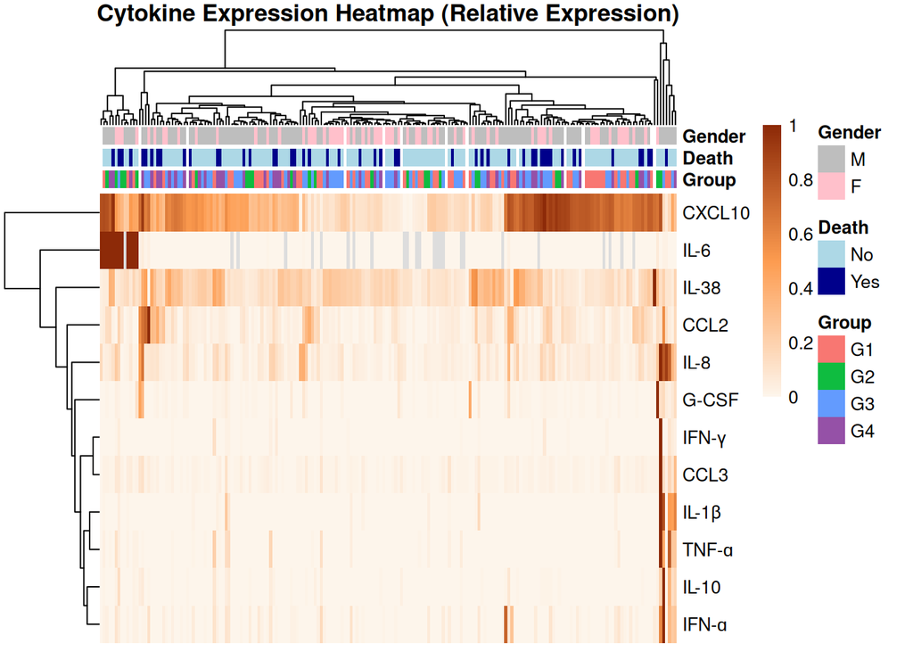

```r
# 3. Handle multiple measurements per patient
# First of all, remove leading/trailing spaces in id
clean_data$id <- trimws(clean_data$id)

# Then, fill in the missing id values for rows with 'NA' using the fill() function, for the
# data aggregation to work correctly
clean_data <- clean_data %>%
  fill(id, .direction = "down")

# Some patients have multiple measurements, taken on different days. To aggregate their cytokine levels, we choose to replace multiple measurements by their mean
aggregated_data <- clean_data %>%
  group_by(id) %>%
  summarise(across(everything(), ~mean(.x, na.rm = TRUE)))

# Merge patient group information (G1-G4)
aggregated_data <- left_join(aggregated_data, table_unique %>% select(id, group), by = "id")
# Merge patient gender information
aggregated_data <- left_join(aggregated_data, table_unique %>% select(id, gender), by = "id")
# Merge patient death information
aggregated_data <- left_join(aggregated_data, table_unique %>% select(id, death), by = "id")

# Scale each cytokine between 0 (min) and 1 (max)
min_max_norm <- function(x) {
  return((x - min(x, na.rm = TRUE))/(max(x, na.rm = TRUE) - min(x, na.rm = TRUE)))
}

# Apply normalization to all cytokine columns (except for id)
normalized_data <- aggregated_data %>%
  mutate(across(-c(id, group, gender, death), min_max_norm))

# Remove unnecessary columns and prepare the data for heatmap
# Keep the first 14 columns of the data frame, except column Day (which contain the cytokine measurements we are interested in plotting) together with group, gender and death
new_normalized_data <- select(normalized_data, c(id, colnames(normalized_data)[3:14], group, gender, death))

# Create annotation data frame for G1-G4 groups, death and gender
annotation_cols <- data.frame(
  Group = factor(new_normalized_data$group),
  Death = factor(normalized_data$death, levels = c("No", "Yes")),
  Gender = factor(normalized_data$gender, levels = c("M", "F"))
)

# Define colors for the groups
group_colors <- list(
  Group = c("G1" = "#F87772", "G2" = "#0FBC40", "G3" = "#639BFE", "G4" = "#9551A7"),
  Death = c("No" = "lightblue", "Yes" = "darkblue"),
  Gender = c("M" = "gray", "F" = "pink")
)

# Make sure we are working with a data.frame and not a tibble
new_normalized_data <- as.data.frame(new_normalized_data)
# Set patient id as rownames
rownames(new_normalized_data) <- new_normalized_data$id

# Assign row names according to patient id
rownames(annotation_cols) <- new_normalized_data$id

# Create heatmap
# Convert to numeric matrix for heatmap, preserve patient id as row names
data_matrix <- as.matrix(new_normalized_data[,-c(1, (ncol(new_normalized_data)-2):ncol(new_normalized_data))]) # Exclude patient id and group, gender and death

# Generate the heatmap
pheatmap(t(data_matrix),
         color = colorRampPalette(c("#FDF5EB", "#FD9C50","#8D2A08"))(100),
         cluster_rows = TRUE,
         cluster_cols = TRUE,
         show_rownames = TRUE,
         show_colnames = FALSE,
         fontsize_row = 10,
         main = "Cytokine Expression Heatmap (Relative Expression)",
         annotation_col = annotation_cols,
         annotation_colors = group_colors)
```

# session info

R version 4.3.3 (2024-02-29) Platform: x86_64-pc-linux-gnu (64-bit) Running under: Ubuntu 24.04.1 LTS

Matrix products: default BLAS: /usr/lib/x86_64-linux-gnu/blas/libblas.so.3.12.0 LAPACK: /usr/lib/x86_64-linux-gnu/lapack/liblapack.so.3.12.0

locale: [1] LC_CTYPE=en_US.UTF-8 LC_NUMERIC=C  
[3] LC_TIME=en_US.UTF-8 LC_COLLATE=en_US.UTF-8  
[5] LC_MONETARY=en_US.UTF-8 LC_MESSAGES=en_US.UTF-8  
[7] LC_PAPER=en_US.UTF-8 LC_NAME=C  
[9] LC_ADDRESS=C LC_TELEPHONE=C  
[11] LC_MEASUREMENT=en_US.UTF-8 LC_IDENTIFICATION=C

time zone: Europe/Madrid tzcode source: system (glibc)

attached base packages: [1] grid stats graphics grDevices utils datasets methods  
[8] base

other attached packages: [1] fuzzyjoin_0.1.6 pheatmap_1.0.12 tidyr_1.3.1 gridExtra_2.3  
[5] readxl_1.4.4 dplyr_1.1.4 corrplot_0.95 ggplot2_3.5.1  
[9] rmarkdown_2.29 outliers_0.15

loaded via a namespace (and not attached): [1] gtable_0.3.6 jsonlite_1.9.0 compiler_4.3.3 crayon_1.5.3  
[5] tidyselect_1.2.1 jquerylib_0.1.4 scales_1.3.0 yaml_2.3.10  
[9] fastmap_1.2.0 R6_2.6.1 labeling_0.4.3 generics_0.1.3  
[13] knitr_1.49 tibble_3.2.1 munsell_0.5.1 RColorBrewer_1.1-3 [17] bslib_0.9.0 pillar_1.10.1 rlang_1.1.5 utf8_1.2.4  
[21] cachem_1.1.0 xfun_0.51 sass_0.4.9 cli_3.6.4  
[25] withr_3.0.2 magrittr_2.0.3 digest_0.6.37 rstudioapi_0.17.1 [29] lifecycle_1.0.4 vctrs_0.6.5 evaluate_1.0.3 glue_1.8.0  
[33] farver_2.1.2 cellranger_1.1.0 colorspace_2.1-1 purrr_1.0.4  
[37] tools_4.3.3 pkgconfig_2.0.3 htmltools_0.5.8.1